# Eigen-Networks

PS STUMPF

22/01/2019

This markdown file contains source code related to Stumpf & MacArthur *Machine learning of stem cell identities from single-cell expression data via regulatory network archetypes*. Frontiers in Genetics 10:2 (2019) https://doi.org/10.3389/fgene.2019.00002

Please cite this paper if you re-use any of the code below.

## Load and transform CyTOF data

Load regulatory network (manually curated using the ChIP-Seq database ChIPBasev2.0 and KEGG).

```r
IRN <- read.table('./RegulatoryNetwork', header=T, sep="\t", stringsAsFactors = FALSE)
colix <- unique(c(IRN$Source.Index, IRN$Target.Index))
```

Load CyTOF data from Zunder et al. (2015) Cell Stem Cell doi: 10.1016/j.stem.2015.01.015. (cytobank accession: 43324).

Data contains 47 features (including 6 condition barcodes, some DNA markers etc.).

```r
mESC.NG <- read.flowSet(path='./cytobank43324/', pattern='NG')
```

Perform logicle transformation on data.

```r
# create transformation function with parameters
lgcl  <- logicleTransform(w = 0.6, t = 10000, m = 4.5)
# create transformList to apply to non-linear features
trans <- transformList(parameters(mESC.NG[[1]])$name[9:46], lgcl)
# apply transformation
mESC.NG <- transform(mESC.NG, trans)
```

## Eigen-networks

Integrate single-cell expression data with regulatory network. Derived expression values can be regarded as the edge-expression of the regulatory network.

```r
# Apply function(X) to each frameset and apply function(x) to each row. Returns a list
IRN.NG <- fsApply(mESC.NG,
                  function(X){ apply(exprs(X), # expression values of cells in flowFrame X
                                     1,        # work along first dimenions (one row [cell] at a time)
                                     function(x){ x[IRN$Source.Index] * (x[IRN$Target.Index] ^ IRN$Sign)  }) },
                  simplify = F)
```

Obtain regulatory network archetypes (aka Eigen-Networks, aka principal components). Run *prcomp* on regulatory network data in 0i conditions, project all other conditions.

```r
# Run prcomp to obtain principal components
pcEdge0i <- prcomp(t(IRN.NG$'NG_CGR8-2i.fcs'), center=T, scale.=T)
```

Calculate the proportion of variance explained.

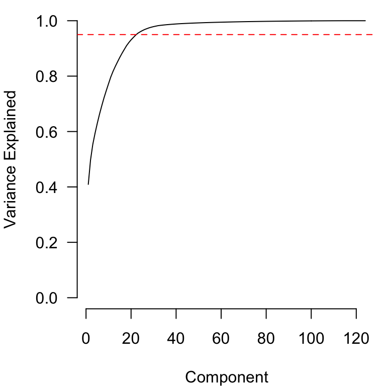

```r
VarExpl <- (pcEdge0i$sdev^2) / sum(pcEdge0i$sdev^2)

# Screeplot
par(mar=c(4,4,.5,.5))
plot(cumsum(VarExpl), type='l', ylim=c(0,1), las=1,
     xlab='Component', ylab='Variance Explained', bty='n'); abline(h=0.95, lty=2, col=2)
```

Function to project unseen data onto principal components.

```r
# Function predictPCA()
predictPCA <- function(object, newdata, cmpnts=1:3)  {
  # function to project newdata onto principal components (object)
  # newdata: matrix with samples (rows) and features (columns)
  predictNewData <- apply(newdata, 2, function(iSample) { ((iSample - object$center) / object$scale) %*% object$rotation[,cmpnts] })
  return(t(predictNewData))
}
```

Extract data of choice and project in principal component space of mESC.NG in 0i conditions.

```r
# specify PCs
pcomp = 1:2
# extract expression matrix (select flowFrame of choice, for instance 2i)
exprmat <- exprs(mESC.NG$'NG_CGR8-2i.fcs')
# project data (select corresponding integrated regulatory network of choice)
xy <- predictPCA(pcEdge0i, IRN.NG$'NG_CGR8-2i.fcs', cmpnts = pcomp)
colnames(xy) <- colnames(pcEdge0i$x[,pcomp])
```

Calculate density of cells in principal component space and visualise using hexbin.

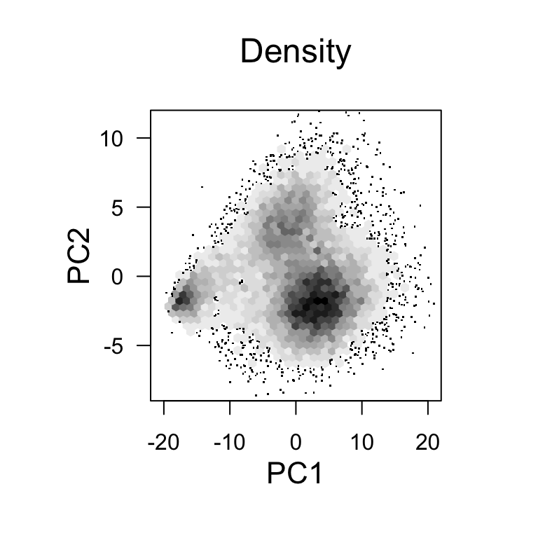

```r
hexpress(xy=xy, exprmat=exprmat, feats='density', pcomp=1:2)
```

Calculate overall expression and visualise using hexbin.

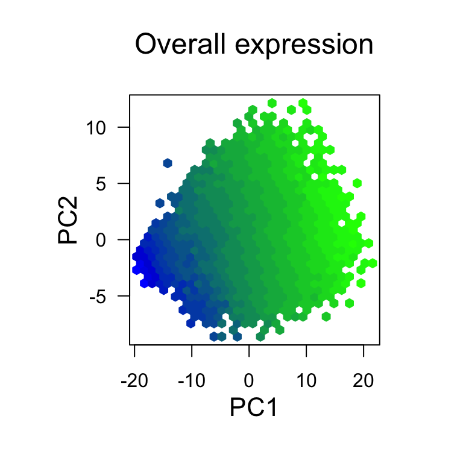

```r
hexpress(xy=xy, exprmat=exprmat, feats='overall', pcomp=1:2, colix=colix)
```

Display node expression using hexbin.

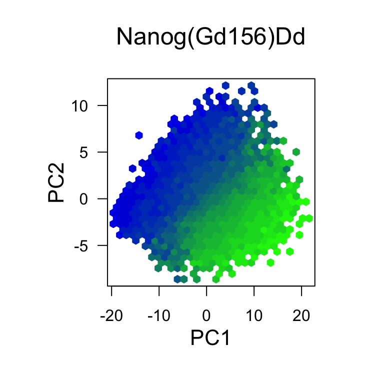

```r
hexpress(xy=xy, exprmat=exprmat, feats='Nanog(Gd156)Dd', pcomp=1:2)
```

Display color bar.

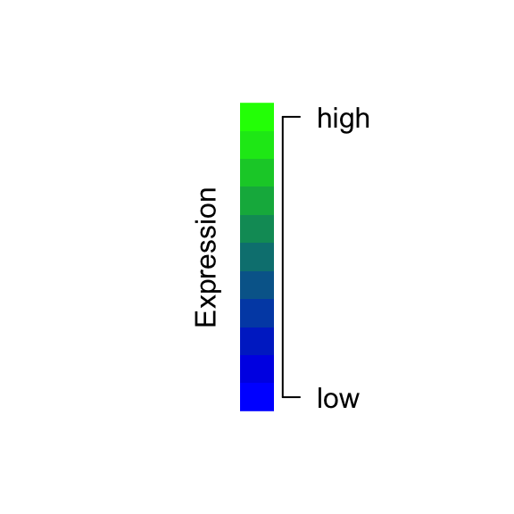

```r
col <- maPalette(low = 'blue', high = 'green', k = 11)

par(mar=c(3 ,7, 3, 7))
  image(t(as.matrix(1:11)), col=col, axes=F)
  axis(4, at = c(0,1),labels = c('low','high'),line = 0.25, las=1)
  mtext(side=2, text='Expression',line = 0.5)
```

## Classification and surprisal analysis

Fit multivariate Gaussian Mixture Model (GMM) with unconstrained co-variance.

```r
# Fit multivariate gaussian mixture model
xyzMc <- Mclust(pcEdge0i$x[,1:3], G=4, modelNames = 'VVV')
# obtain density
xyzMc.density <- densityMclust(pcEdge0i$x[,1:3], G=4, modelNames = 'VVV')
```

Display total variance.

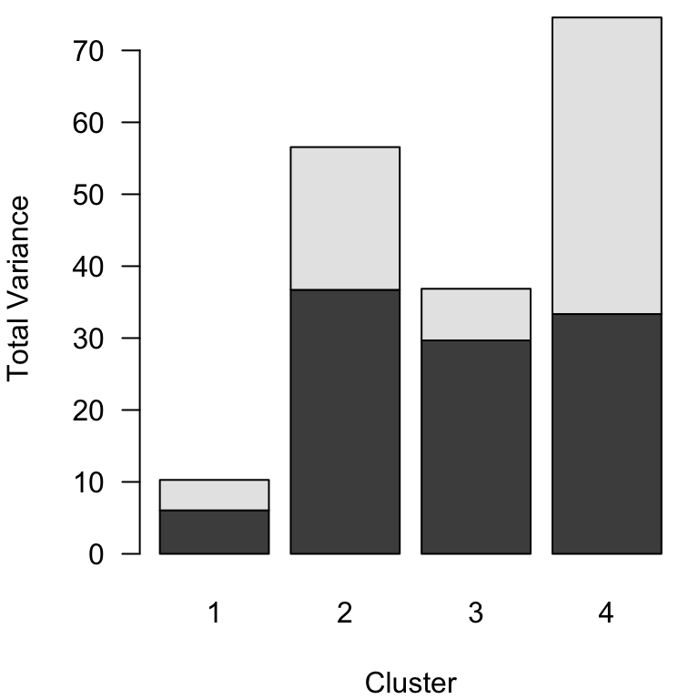

```r
# total variance (trace of covariance matrix + and sum of across remaining off-diagona covariance matrix)
GMMvar <- rbind( apply(xyzMc$parameters$variance$sigma, 3,
                       function(x){sum(diag(x))}),
                 apply(xyzMc$parameters$variance$sigma, 3,
                       function(x){sum(abs(x))}) - apply(xyzMc$parameters$variance$sigma, 3,
                                                         function(x){sum(diag(x))})
                 )[,c(3,1,2,4)]
rownames(GMMvar) <- c('Trace','OffDiagonal')

# Plot results
par(mar=c(4,4,.5,.5))
barplot(GMMvar, las=1, names=1:4, xlab='Cluster', ylab='Total Variance')
```

Calculate centroid Eigen-Network for each cluster and export for external visualisation (e.g. using Cytoscape or yEd). See figure 4B in Stumpf & MacArthur (2019).

```r
# prepare data for export 1/3
clusterface <- cbind(( pcEdge0i$center + pcEdge0i$scale * t(xyzMc$parameters$mean[,1] %*% t(pcEdge0i$rotation[,1:3])) ),
                     ( pcEdge0i$center + pcEdge0i$scale * t(xyzMc$parameters$mean[,2] %*% t(pcEdge0i$rotation[,1:3])) ),
                     ( pcEdge0i$center + pcEdge0i$scale * t(xyzMc$parameters$mean[,3] %*% t(pcEdge0i$rotation[,1:3])) ),
                     ( pcEdge0i$center + pcEdge0i$scale * t(xyzMc$parameters$mean[,4] %*% t(pcEdge0i$rotation[,1:3])) ))
colnames(clusterface) <- c('centroid-c1', 'centroid-c2', 'centroid-c3', 'centroid-c4')
rownames(clusterface) <- c()
# prepare data for export 2/3
pcexport <- cbind(pcEdge0i$center, pcEdge0i$scale)
colnames(pcexport) <- c('center', 'scale')
# prepare data for export 3/3
pcexport <- cbind(pcexport, pcEdge0i$rotation)
rownames(pcexport) <- c()

# write matrix for network
write.table(cbind(IRN, clusterface, pcexport),
                  file='IRN-NG.tgf', sep='\t', quote=F, row.names = F, col.names = T)
```

Calculate surprisal and visualise as beanplots.

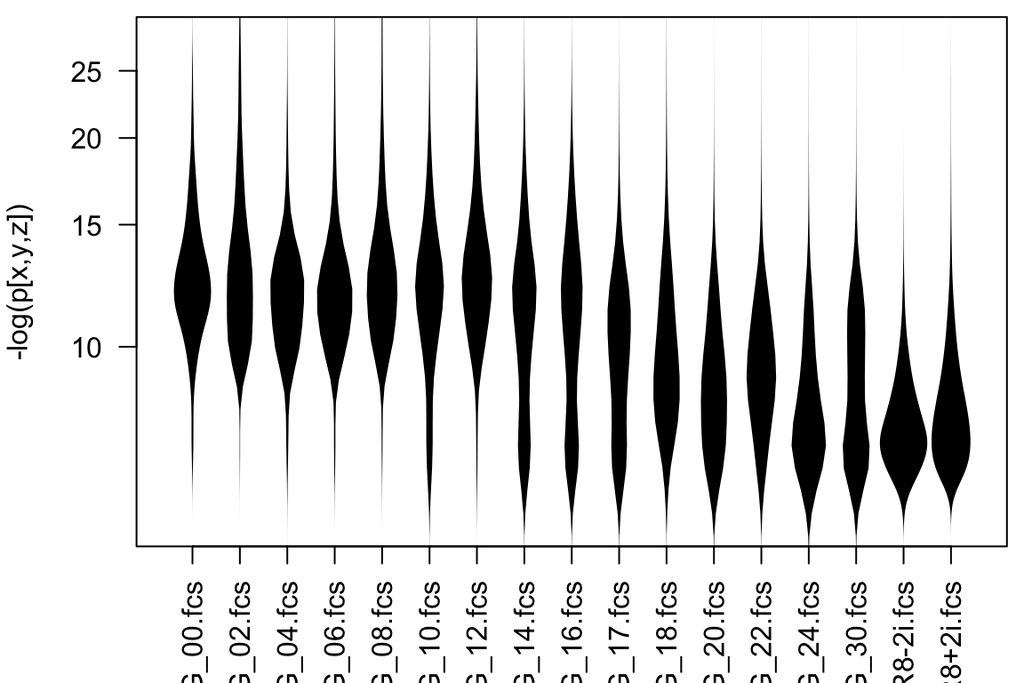

```r
# Density - Surprisal
a <- lapply( IRN.NG, function(x) {-log(predict(xyzMc.density, newdata=predictPCA(pcEdge0i, x[,])))})
par(mar=c(4,4,.5,.5))
beanplot(a, what=c(F,T,F,F), cutmin=0, cutmax=40, ylim=c(5.5,28), log='y', las=2, bw=0.05, maxwidth = 1, border=NA, ylab='-log(p[x,y,z])')
```

Classification of points using Gaussian Mixture Model.

```r
# Classification
xyzDA   <- MclustDA(pcEdge0i$x[,1:3], xyzMc$classification, G=4, modelNames='VVV')
xyzDAcv <- cvMclustDA(xyzDA, nfold=10)

pcEdge0i.classification <- do.call(cbind, lapply(IRN.NG, function(x){table(predict(xyzDA, newdata=predictPCA(pcEdge0i, x))$classification)}))

# which cells are classified correctly?
pcEdge0i.classification.retained <- lapply(IRN.NG, function(x){rejectOption(xyzMc, predictPCA(pcEdge0i, x), G=1:4, alpha=0.1) })
```